# Context:

According to the World Health Organization (WHO) stroke is the 2nd leading cause of death globally, responsible for approximately 11% of total deaths.

# Problem Statement:

In this project, we use this dataset to predict whether a patient is likely to get a stroke or not based on our parameters.

## Attribute Information:

1. id: unique identifier
2. gender: "Male", "Female" or "Other"
3. age: age of the patient
4. hypertension: 0 if the patient doesn't have hypertension, 1 if the patient has hypertension
5. heart_disease: 0 if the patient doesn't have any heart diseases, 1 if the patient has a heart disease
6. ever_married: "No" or "Yes"
7. work_type: "children", "Govt_jov", "Never_worked", "Private" or "Self-employed"
8. Residence_type: "Rural" or "Urban"
9. avg_glucose_level: average glucose level in blood
10. bmi: body mass index
11. smoking_status: "formerly smoked", "never smoked", "smokes" or "Unknown"*
12. stroke: 1 if the patient had a stroke or 0 if not

## Exploratory Data Analysis

```python
# IMPORT DATASET
%matplotlib inline
import numpy as np
import pandas as pd
import matplotlib.pyplot as plt
import seaborn as sns
```

```python
# READ CSV AS DATAFRAME
stroke_df = pd.read_csv('healthcare-dataset-stroke-data.csv')
stroke_df.head()
```

|  | id | gender | age | hypertension | heart_disease | ever_married | work_type | Residence_type | avg_glucose_level | bmi | smoking_status | stroke |
| --- | --- | --- | --- | --- | --- | --- | --- | --- | --- | --- | --- | --- |
| 0 | 9046 | Male | 67.0 | 0 | 1 | Yes | Private | Urban | 228.69 | 36.6 | formerly smoked | 1 |
| 1 | 51676 | Female | 61.0 | 0 | 0 | Yes | Self-employed | Rural | 202.21 | NaN | never smoked | 1 |
| 2 | 31112 | Male | 80.0 | 0 | 1 | Yes | Private | Rural | 105.92 | 32.5 | never smoked | 1 |
| 3 | 60182 | Female | 49.0 | 0 | 0 | Yes | Private | Urban | 171.23 | 34.4 | smokes | 1 |
| 4 | 1665 | Female | 79.0 | 1 | 0 | Yes | Self-employed | Rural | 174.12 | 24.0 | never smoked | 1 |

- We will not be needing id for anything, so it will be dropped.

```python
# DROPPING ID COLUMN - IT IS UNNECESSARY
stroke_df.drop('id', axis=1, inplace=True)
stroke_df.describe()
```

|  | age | hypertension | heart_disease | avg_glucose_level | bmi | stroke |
| --- | --- | --- | --- | --- | --- | --- |
| count | 5110.000000 | 5110.000000 | 5110.000000 | 5110.000000 | 4909.000000 | 5110.000000 |
| mean | 43.226614 | 0.097456 | 0.054012 | 106.147677 | 28.893237 | 0.048728 |
| std | 22.612647 | 0.296607 | 0.226063 | 45.283560 | 7.854067 | 0.215320 |
| min | 0.080000 | 0.000000 | 0.000000 | 55.120000 | 10.300000 | 0.000000 |
| 25% | 25.000000 | 0.000000 | 0.000000 | 77.245000 | 23.500000 | 0.000000 |
| 50% | 45.000000 | 0.000000 | 0.000000 | 91.885000 | 28.100000 | 0.000000 |
| 75% | 61.000000 | 0.000000 | 0.000000 | 114.090000 | 33.100000 | 0.000000 |
| max | 82.000000 | 1.000000 | 1.000000 | 271.740000 | 97.600000 | 1.000000 |

```python
# GENERAL INFORMATION OF DATA
stroke_df.info()
```

```
<class 'pandas.core.frame.DataFrame'>
RangeIndex: 5110 entries, 0 to 5109
Data columns (total 11 columns):
 #   Column             Non-Null Count  Dtype
---  ------             --------------  -----
 0   gender             5110 non-null   object
 1   age                5110 non-null   float64
 2   hypertension       5110 non-null   int64
 3   heart_disease      5110 non-null   int64
 4   ever_married       5110 non-null   object
 5   work_type          5110 non-null   object
 6   Residence_type     5110 non-null   object
 7   avg_glucose_level  5110 non-null   float64
 8   bmi                4909 non-null   float64
 9   smoking_status     5110 non-null   object
 10  stroke             5110 non-null   int64
dtypes: float64(3), int64(3), object(5)
memory usage: 439.3+ KB
```

## Data Pre-Processing

- The bmi column has missing values. It is a numerical attribute, therefore we will imputate using the mean of each corresponding gender.

```python
f_bmi = stroke_df[stroke_df['gender'] == 'Female'].mean()['bmi']
m_bmi = stroke_df[stroke_df['gender'] == 'Male'].mean()['bmi']

stroke_df[stroke_df['gender']=='Female'] = stroke_df[stroke_df['gender'] == 'Female'].fillna(f_bmi)
stroke_df[stroke_df['gender']=='Male'] = stroke_df[stroke_df['gender'] == 'Male'].fillna(m_bmi)
```

```python
# initializing empty lists to store values in
cat_vars = []
num_vars = []
# looping through the dataframe
for col in stroke_df:
    # if categorical values, then store them in the cat_vars list
    if(stroke_df[col].dtype == 'object'):
        cat_vars.append(col)
    # if numerical
    elif(stroke_df[col].dtype in ('int64', 'float64')):
        # if unique values are less than 4, then append to the cat_vars list
        if(stroke_df[col].nunique() < 4):
            cat_vars.append(col)
        # if not, then store all the continuous data in the num_vars list
        else:
            num_vars.append(col)
# loop through the categorical values and print out the count for each category
for col in cat_vars:
    print(stroke_df[col].value_counts(), '\n')
```

```
Female    2994
Male      2115
Other        1
Name: gender, dtype: int64

0    4612
1     498
Name: hypertension, dtype: int64

0    4834
1     276
Name: heart_disease, dtype: int64

Yes    3353
No     1757
Name: ever_married, dtype: int64

Private          2925
Self-employed     819
children          687
Govt_job          657
Never_worked       22
Name: work_type, dtype: int64

Urban    2596
Rural    2514
Name: Residence_type, dtype: int64

never smoked       1892
Unknown            1544
formerly smoked     885
smokes              789
Name: smoking_status, dtype: int64

0    4861
1     249
Name: stroke, dtype: int64
```

- We can see poor value counts for gender:'Other' and work_type:'Never_worked'. We also have an 'Unknown' value for smoking_status, so we will imputate using the most common value.

```python
stroke_df = stroke_df[stroke_df.gender != 'Other']
stroke_df = stroke_df[stroke_df.work_type != 'Never_worked']
# Removing "unknown" smoking status
stroke_df['smoking_status'].replace('Unknown', np.nan, inplace=True)
# Getting the mode for smoking status if null
stroke_df['smoking_status'].fillna(stroke_df['smoking_status'].mode()[0], inplace=True)
```

## Data Visualization - Boxplots

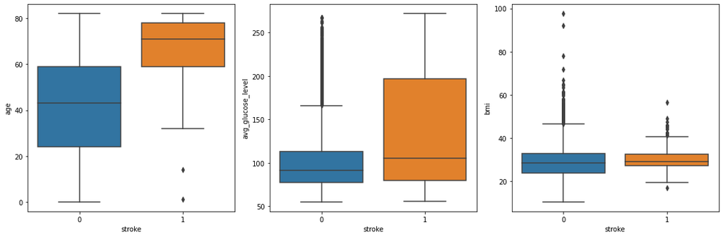

```python
# figure sizing
fig, axes = plt.subplots(nrows=1, ncols=3, figsize=(15,5))
col = iter(num_vars)
# loop through to plot all 3 different numerical data
for j in range(3):
    # boxplots
    sns.boxplot(ax=axes[j], x='stroke', y=next(col), data=stroke_df)
plt.tight_layout()
plt.show()
```

### Interpretation:

- Older individuals are more prone to stroke
- Individuals that have a higher average glucose level are more prone to stroke
- BMI and stroke do not show much of a correlation

## Data Visualization - KDE Plots

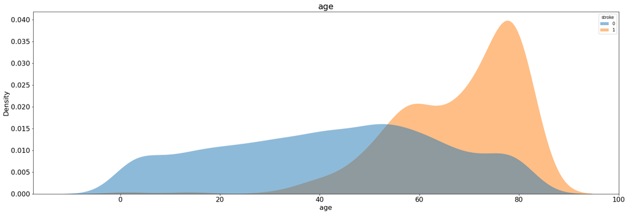

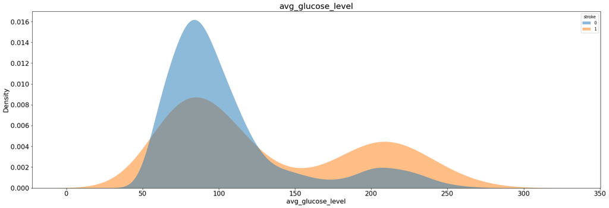

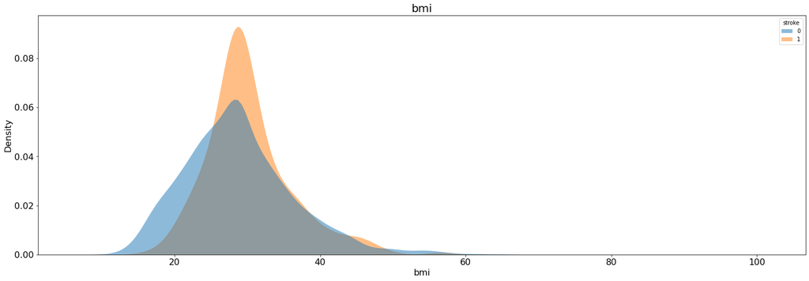

```python
cnt = 0
max_in_row = 1
for x in num_vars:
    plt.figure(cnt//max_in_row, figsize=(25,8))
    plt.subplot(1, max_in_row, (cnt)%max_in_row + 1)
    plt.title(x, fontsize=20)
    plt.xticks(fontsize=16)
    plt.yticks(fontsize=16)
    plt.xlabel(x, fontsize=16)
    plt.ylabel('Density', fontsize=16)
    sns.kdeplot(data=stroke_df, x=x, hue="stroke", fill=True, common_norm=False, alpha=.5, linewidth=0);
    cnt += 1
```

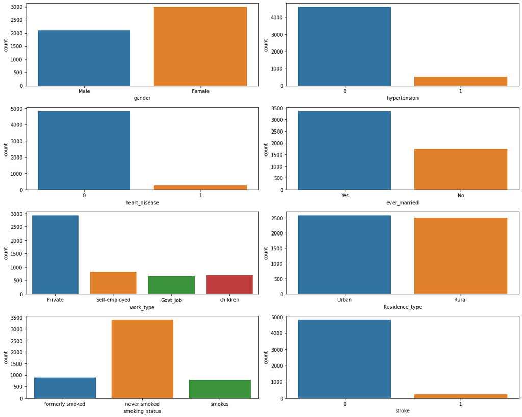

```python
# figure sizing
fig, axes = plt.subplots(nrows=4, ncols=2, figsize=(15,12))
col = iter(cat_vars)
# double for loop through for 4x2 of plots
for i in range(4):
    for j in range(2):
        sns.countplot(ax=axes[i][j], x=stroke_df[next(col)])
plt.tight_layout()
plt.show()
```

## Mapping and Dummy Variables

```python
# mappings for marriage, residence type, and gender
ever_married_mappings = {'No':0,'Yes':1}
Residence_type_mappings = {'Rural':0, 'Urban':1}
gender_mappings = {'Male':0, 'Female':1}

# apply mappings
stroke_df['ever_married'] = stroke_df['ever_married'].map(ever_married_mappings)
stroke_df['Residence_type'] = stroke_df['Residence_type'].map(Residence_type_mappings)
stroke_df['gender'] = stroke_df['gender'].map(gender_mappings)

# Dummy variables for encoding
encoded_columns = ['work_type', 'smoking_status']
stroke_df = pd.get_dummies(stroke_df, encoded_columns, drop_first=True)
stroke_df.head()
```

|  | gender | age | hypertension | heart_disease | ever_married | Residence_type | avg_glucose_level | bmi | stroke | work_type_Private | work_type_Self-employed | work_type_children | smoking_status_never smoked | smoking_status_smokes |
| --- | --- | --- | --- | --- | --- | --- | --- | --- | --- | --- | --- | --- | --- | --- |
| 0 | 0 | 67.0 | 0 | 1 | 1 | 1 | 228.69 | 36.600000 | 1 | 1 | 0 | 0 | 0 | 0 |
| 1 | 1 | 61.0 | 0 | 0 | 1 | 0 | 202.21 | 29.065758 | 1 | 0 | 1 | 0 | 1 | 0 |
| 2 | 0 | 80.0 | 0 | 1 | 1 | 0 | 105.92 | 32.500000 | 1 | 1 | 0 | 0 | 1 | 0 |
| 3 | 1 | 49.0 | 0 | 0 | 1 | 1 | 171.23 | 34.400000 | 1 | 1 | 0 | 0 | 0 | 1 |
| 4 | 1 | 79.0 | 1 | 0 | 1 | 0 | 174.12 | 24.000000 | 1 | 0 | 1 | 0 | 1 | 0 |

## Resampling and Create/Train Model

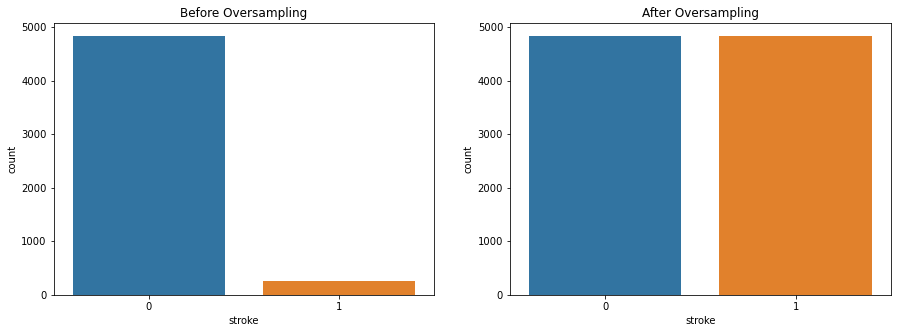

```python
# IMPORT LIBRARIES
%matplotlib inline
import matplotlib.pyplot as plt
import numpy as np
import pandas as pd

# X is all attributes that are not stroke
X = stroke_df.drop('stroke', axis=1)
# y is just the stroke column
y = stroke_df['stroke']

fig, axes = plt.subplots(nrows=1, ncols=2, figsize=(15,5))
sns.countplot(ax=axes[0], x=y).set(title='Before Oversampling')

# we have to resample the data here because there is a significant amount of difference of those who did have a stroke and who didn't
from imblearn.over_sampling import SMOTE
sm = SMOTE(random_state=42)
X, y = sm.fit_resample(X, y)
# plotting the amount after resampling
sns.countplot(ax=axes[1], x=y).set(title='After Oversampling')
plt.show()
```

```python
# Before Scaling the data
pd.DataFrame(X).head()
```

|  | gender | age | hypertension | heart_disease | ever_married | Residence_type | avg_glucose_level | bmi | work_type_Private | work_type_Self-employed | work_type_children | smoking_status_never smoked | smoking_status_smokes |
| --- | --- | --- | --- | --- | --- | --- | --- | --- | --- | --- | --- | --- | --- |
| 0 | 0 | 67.0 | 0 | 1 | 1 | 1 | 228.69 | 36.600000 | 1 | 0 | 0 | 0 | 0 |
| 1 | 1 | 61.0 | 0 | 0 | 1 | 0 | 202.21 | 29.065758 | 0 | 1 | 0 | 1 | 0 |
| 2 | 0 | 80.0 | 0 | 1 | 1 | 0 | 105.92 | 32.500000 | 1 | 0 | 0 | 1 | 0 |
| 3 | 1 | 49.0 | 0 | 0 | 1 | 1 | 171.23 | 34.400000 | 1 | 0 | 0 | 0 | 1 |
| 4 | 1 | 79.0 | 1 | 0 | 1 | 0 | 174.12 | 24.000000 | 0 | 1 | 0 | 1 | 0 |

```python
# SCALING OUR DATA
from sklearn.preprocessing import StandardScaler
scaler = StandardScaler()
X = pd.DataFrame(data=scaler.fit_transform(X), columns=X.columns)
# After Scaling the data
X.head()
```

|  | gender | age | hypertension | heart_disease | ever_married | Residence_type | avg_glucose_level | bmi | work_type_Private | work_type_Self-employed | work_type_children | smoking_status_never smoked | smoking_status_smokes |
| --- | --- | --- | --- | --- | --- | --- | --- | --- | --- | --- | --- | --- | --- |
| 0 | -0.912646 | 0.531338 | -0.303479 | 4.274915 | 0.620209 | 1.200917 | 1.997151 | 1.090833 | 1.030647 | -0.373936 | -0.277103 | -1.008302 | -0.330147 |
| 1 | 1.095715 | 0.259939 | -0.303479 | -0.233923 | 0.620209 | -0.832697 | 1.516015 | -0.055841 | -0.970264 | 2.674256 | -0.277103 | 0.991766 | -0.330147 |
| 2 | -0.912646 | 1.119370 | -0.303479 | 4.274915 | 0.620209 | -0.832697 | -0.233554 | 0.466833 | 1.030647 | -0.373936 | -0.277103 | 0.991766 | -0.330147 |
| 3 | 1.095715 | -0.282860 | -0.303479 | -0.233923 | 0.620209 | 1.200917 | 0.953115 | 0.756004 | 1.030647 | -0.373936 | -0.277103 | -1.008302 | 3.028952 |
| 4 | 1.095715 | 1.074136 | 3.295124 | -0.233923 | 0.620209 | -0.832697 | 1.005625 | -0.826824 | -0.970264 | 2.674256 | -0.277103 | 0.991766 | -0.330147 |

```python
# Splitting the data
from sklearn.model_selection import train_test_split
X_train, X_test, y_train, y_test = train_test_split(X, y, test_size=0.3, random_state=42)
```

## Part I. K-Nearest Neighbors (KNN) - Holdout method and repeated sampling

```
Average: 90.58%
```

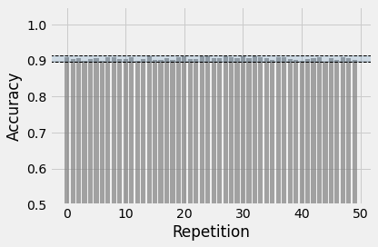

```python
# import library
from sklearn.neighbors import KNeighborsClassifier
# we can only have 2 clusters - individual has a stroke or they do not
clf_1 = KNeighborsClassifier(2)
clf_1.fit(X_train, y_train)

# random sampling
rng = np.random.RandomState(seed=12345)
seeds = np.arange(10**5)
rng.shuffle(seeds)
seeds = seeds[:50]

pred_2 = []

for i in seeds:
    X_train, X_test, y_train, y_test = train_test_split(X, y, test_size=0.5, random_state=i, stratify=y)
    y_pred_i = clf_1.fit(X_train, y_train).predict(X_test)
    y_pred_i_acc = np.mean(y_test == y_pred_i)
    pred_2.append(y_pred_i_acc)
pred_2 = np.asarray(pred_2)
print('Average: %.2f%%' % (pred_2.mean()*100))

# plotting accuracy vs repetition graph
with plt.style.context(('fivethirtyeight')):
    plt.bar(range(0, pred_2.shape[0]), pred_2, color='gray', alpha=0.7)
    plt.axhline(pred_2.max(), color='k', linewidth=1, linestyle='--')
    plt.axhline(pred_2.min(), color='k', linewidth=1, linestyle='--')
    plt.axhspan(pred_2.min(), pred_2.max(), alpha=0.2, color='steelblue')
    plt.ylim([0, pred_2.max() + 0.1])
    plt.xlabel('Repetition')
    plt.ylabel('Accuracy')
    plt.ylim([0.5, 1.05])
    plt.tight_layout()
    #plt.savefig('figures/model-eval-iris_0.svg')
    plt.show()
```

```
Average: 92.76%
```

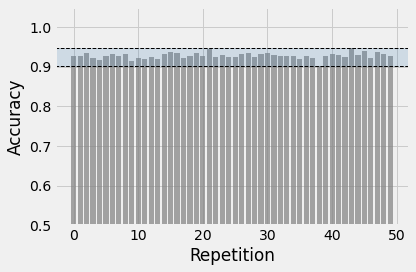

```python
rng = np.random.RandomState(seed=12345)
seeds = np.arange(10**5)
rng.shuffle(seeds)
seeds = seeds[:50]

pred_2 = []

for i in seeds:
    X_train, X_test, y_train, y_test = train_test_split(X, y,
                                                        test_size=0.1,
                                                        random_state=i,
                                                        stratify=y)
    y_pred_i = clf_1.fit(X_train, y_train).predict(X_test)
    y_pred_i_acc = np.mean(y_test == y_pred_i)
    pred_2.append(y_pred_i_acc)

pred_2 = np.asarray(pred_2)
print('Average: %.2f%%' % (pred_2.mean()*100))

with plt.style.context(('fivethirtyeight')):
    plt.bar(range(0, pred_2.shape[0]), pred_2, color='gray', alpha=0.7)
    plt.axhline(pred_2.max(), color='k', linewidth=1, linestyle='--')
    plt.axhline(pred_2.min(), color='k', linewidth=1, linestyle='--')
    plt.axhspan(pred_2.min(), pred_2.max(), alpha=0.2, color='steelblue')
    plt.ylim([0, pred_2.max() + 0.1])
    plt.xlabel('Repetition')
    plt.ylabel('Accuracy')
    plt.ylim(0.5, 1.05)
    plt.tight_layout()
    plt.show()
```

### How many were samples were trained and tested?

```python
A = stroke_df.drop('stroke', axis=1).values
b = stroke_df['stroke']
A, b = sm.fit_resample(A, b)
X_train2, X_test2, y_train2, y_test2 = train_test_split(A, b,
                                                        test_size=0.3,
                                                        random_state=42,
                                                        stratify=b)
print('Number of train examples:', y_train2.shape[0])
print('Number of test examples:', y_test2.shape[0])
print('Labels:', np.asarray(y_train2.unique()))
```

```
Number of train examples: 6773
Number of test examples: 2903
Labels: [0 1]
```

## Part II. Logistic Regression - Pessimistic Bias in Holdout

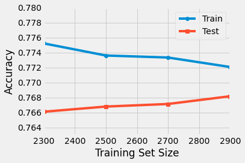

```python
from sklearn.linear_model import LogisticRegression

clf_2 = LogisticRegression(penalty='l2',
                            dual=False,
                            tol=0.0001,
                            C=0.000001,
                            fit_intercept=True,
                            intercept_scaling=1,
                            class_weight=None,
                            random_state=12,
                            solver='lbfgs',
                            max_iter=1000,
                            multi_class='multinomial',
                            verbose=0,
                            warm_start=False,
                            n_jobs=1)
pred_train, pred_test = [], []

intervals = np.arange(500, X_train.shape[0] + 1, 200)

for i in intervals:
    clf_2.fit(X_train2[:i], y_train2[:i])
    p_train = clf_2.score(X_train2[:i], y_train2[:i])
    p_test = clf_2.score(X_test2, y_test2)
    pred_train.append(p_train)
    pred_test.append(p_test)

with plt.style.context(('fivethirtyeight')):
    plt.plot(intervals, pred_train, marker='o', label='Train')
    plt.plot(intervals, pred_test, marker='s', label='Test')
    plt.legend(loc='best', numpoints=1)
#   plt.xlim([430, X_train2.shape[0] + X_test.shape[0]])
    plt.xlim([2300,2900])
    plt.axvspan(X_train2.shape[0],
                X_train2.shape[0] + X_test.shape[0],
                alpha=0.2,
                color='steelblue')
    plt.ylim([0.763, 0.78])
    plt.xlabel('Training Set Size')
    plt.ylabel('Accuracy')
    plt.tight_layout()
    #plt.savefig('figures/model-eval-mnist_0.svg')
```

## Part III. Random Forest Classifier - Pessimistic Bias in Holdout

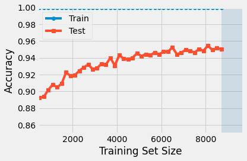

```python
from sklearn.ensemble import RandomForestClassifier


clf_2 = RandomForestClassifier(n_estimators=100, random_state=123)

pred_train, pred_test = [], []

intervals = np.arange(500, X_train.shape[0] + 1, 200)

for i in intervals:
    clf_2.fit(X_train[:i], y_train[:i])
    p_train = clf_2.score(X_train[:i], y_train[:i])
    p_test = clf_2.score(X_test, y_test)
    pred_train.append(p_train)
    pred_test.append(p_test)


with plt.style.context(('fivethirtyeight')):
    plt.plot(intervals, pred_train, marker='o', label='Train')
    plt.plot(intervals, pred_test, marker='s', label='Test')
    plt.legend(loc='best', numpoints=1)
    plt.xlim([430, X_train.shape[0] + X_test.shape[0]])
    plt.axvspan(X_train.shape[0],
                X_train.shape[0] + X_test.shape[0],
                alpha=0.2,
                color='steelblue')
    plt.ylim([0.85, 1.0])
    plt.xlabel('Training Set Size')
    plt.ylabel('Accuracy')
    plt.tight_layout()
    #plt.savefig('figures/model-eval-mnist_0.svg')
```

## Part IV. K Nearest Neighbors - Pessimistic Bias in Holdout

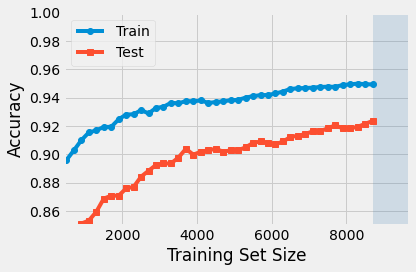

```python
from sklearn.neighbors import KNeighborsClassifier

clf_2 = KNeighborsClassifier(n_neighbors=3)

pred_train, pred_test = [], []

intervals = np.arange(500, X_train.shape[0] + 1, 200)

for i in intervals:
    clf_2.fit(X_train[:i], y_train[:i])
    p_train = clf_2.score(X_train[:i], y_train[:i])
    p_test = clf_2.score(X_test, y_test)
    pred_train.append(p_train)
    pred_test.append(p_test)

with plt.style.context(('fivethirtyeight')):
    plt.plot(intervals, pred_train, marker='o', label='Train')
    plt.plot(intervals, pred_test, marker='s', label='Test')
    plt.legend(loc='best', numpoints=1)
    plt.xlim([430, X_train.shape[0] + X_test.shape[0]])
    plt.axvspan(X_train.shape[0],
                X_train.shape[0] + X_test.shape[0],
                alpha=0.2,
                color='steelblue')
    plt.ylim([0.85, 1.0])
    plt.xlabel('Training Set Size')
    plt.ylabel('Accuracy')
    plt.tight_layout()
```

## Bootstrapping

```python
from sklearn.neighbors import KNeighborsClassifier

rng = np.random.RandomState(seed=12345)


clf = KNeighborsClassifier(n_neighbors=3,
                            weights='uniform',
                            algorithm='kd_tree',
                            leaf_size=30,
                            p=2,
                            metric='minkowski',
                            metric_params=None,
                            n_jobs=1)

idx = np.arange(y.shape[0])

accuracies = []

for i in range(200):

#     train_idx = rng.choice(idx, size=idx.shape[0], replace=True)
#     test_idx = np.setdiff1d(idx, train_idx, assume_unique=False)

#     boot_train_X, boot_train_y = X[train_idx], y[train_idx]
#     boot_test_X, boot_test_y = X[test_idx], y[test_idx]
    boot_train_X, boot_test_X, boot_train_y, boot_test_y = train_test_split(X, y, test_size=0.3, random_state=i)

    clf.fit(boot_train_X, boot_train_y)
    acc = clf.score(boot_test_X, boot_test_y)
    accuracies.append(acc)
```

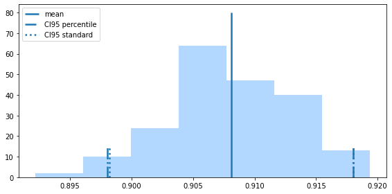

```python
mean = np.mean(accuracies)

#se = np.sqrt( (1. / (100-1)) * np.sum([(acc - mean)**2 for acc in ,→accuracies]))
#ci = 1.984 * se

se = np.sqrt( (1. / (200-1)) * np.sum([(acc - mean)**2 for acc in accuracies]))
ci = 1.97 * se

lower = np.percentile(accuracies, 2.5)
upper = np.percentile(accuracies, 97.5)

fig, ax = plt.subplots(figsize=(8, 4))
ax.vlines(mean, [0], 80, lw=2.5, linestyle='-', label='mean')
#ax.vlines(med, [0], 60, lw=2.5, linestyle='--', label='median')
ax.vlines(lower, [0], 15, lw=2.5, linestyle='-.', label='CI95 percentile')
ax.vlines(upper, [0], 15, lw=2.5, linestyle='-.')

ax.vlines(mean + ci, [0], 15, lw=2.5, linestyle=':', label='CI95 standard')
ax.vlines(mean - ci, [0], 15, lw=2.5, linestyle=':')


ax.hist(accuracies, bins=7,
        color='#0080ff', edgecolor="none",
        alpha=0.3)
plt.legend(loc='upper left')

#plt.xlim([0.85, 95])
plt.tight_layout()
#plt.savefig('figures/bootstrap-histo-1.svg')

plt.show()
```

```python
from mlxtend.data import mnist_data
from sklearn.linear_model import LogisticRegression

rng = np.random.RandomState(seed=12345)


clf = LogisticRegression(penalty='l2',
                        dual=False,
                        tol=0.0001,
                        C=0.000001,
                        fit_intercept=True,
                        intercept_scaling=1,
                        class_weight=None,
                        random_state=12,
                        solver='lbfgs',
                        max_iter=1000,
                        multi_class='multinomial',
                        verbose=0,
                        warm_start=False,
                        n_jobs=1)

idx = np.arange(y.shape[0])

accuracies = []

A = stroke_df.drop('stroke', axis=1).values
b = stroke_df['stroke']
A = scaler.fit_transform(A)
for i in range(200):
#     train_idx = rng.choice(idx, size=idx.shape[0], replace=True)
#     test_idx = np.setdiff1d(idx, train_idx, assume_unique=False)

#     boot_train_X, boot_train_y = X[train_idx], y[train_idx]
#     boot_test_X, boot_test_y = X[test_idx], y[test_idx]

    boot_train_X, boot_test_X, boot_train_y, boot_test_y = train_test_split(A, b, test_size=0.3,random_state=i)

    clf.fit(boot_train_X, boot_train_y)
    acc = clf.score(boot_test_X, boot_test_y)
    accuracies.append(acc)
```

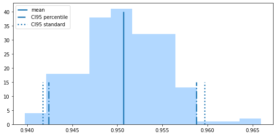

```python
mean = np.mean(accuracies)


#se = np.sqrt( (1. / (100-1)) * np.sum([(acc - mean)**2 for acc in,→accuracies]))
#ci = 1.984 * se


se = np.sqrt( (1. / (200-1)) * np.sum([(acc - mean)**2 for acc in accuracies]))
ci = 1.97 * se


lower = np.percentile(accuracies, 2.5)
upper = np.percentile(accuracies, 97.5)


fig, ax = plt.subplots(figsize=(8, 4))
ax.vlines(mean, [0], 40, lw=2.5, linestyle='-', label='mean')
#ax.vlines(med, [0], 60, lw=2.5, linestyle='--', label='median')
ax.vlines(lower, [0], 15, lw=2.5, linestyle='-.', label='CI95 percentile')
ax.vlines(upper, [0], 15, lw=2.5, linestyle='-.')

ax.vlines(mean + ci, [0], 15, lw=2.5, linestyle=':', label='CI95 standard')
ax.vlines(mean - ci, [0], 15, lw=2.5, linestyle=':')

ax.hist(accuracies, bins=11,
        color='#0080ff', edgecolor="none",
        alpha=0.3)
plt.legend(loc='upper left')

#plt.xlim([0.55, .75])
plt.tight_layout()

# plt.savefig('figures/bootstrap-histo-2.svg')

plt.show()
```

## Out of Bag Bootstrap

```python
from mlxtend.evaluate import BootstrapOutOfBag

oob = BootstrapOutOfBag(n_splits=3)
for train, test in oob.split(np.array([1,2,3,4,5])):
    print(train, test)
```

```
[3 4 1 1 0] [2]
[3 0 4 1 1] [2]
[4 0 3 4 4] [1 2]
```

```python
from sklearn.tree import DecisionTreeClassifier
from sklearn.model_selection import cross_val_score

model = DecisionTreeClassifier()
```

```python
cv_scores = cross_val_score(model, X, y, cv=5)
print('CV scores', cv_scores)
print('Mean CV score', np.mean(cv_scores))
print('CV score Std', np.std(cv_scores))
```

```
CV scores [0.87551653 0.92144703 0.91937984 0.9250646  0.93126615]
Mean CV score 0.9145348303329275
CV score Std 0.01992231706275002
```

```python
bootstrap_scores = \
    cross_val_score(model, X, y,
                    cv=BootstrapOutOfBag(n_splits=5, random_seed=456))
print('Bootstrap scores', bootstrap_scores)
print('Mean Boostrap score', np.mean(bootstrap_scores))
print('Score Std', np.std(bootstrap_scores))
```

```
Bootstrap scores [0.90462911 0.90568694 0.90798758 0.91280045 0.90598769]
Mean Boostrap score 0.907418353468428
Score Std 0.0029022549312150807
```

```python
boostrap_scores = \
    cross_val_score(model, X, y,
                    cv=BootstrapOutOfBag(n_splits=200, random_seed=456))

print('Mean Bootstrap score', np.mean(bootstrap_scores))
print('Score Std', np.std(bootstrap_scores))
```

```
Mean Bootstrap score 0.907418353468428
Score Std 0.0029022549312150807
```

```python
lower = np.percentile(bootstrap_scores, 2.5)
upper = np.percentile(bootstrap_scores, 97.5)
print('95%% Confidence interval: [%.2f, %.2f]' % (100*lower, 100*upper))
```

```
95% Confidence interval: [90.47, 91.23]
```

```python
from mlxtend.evaluate import bootstrap_point632_score

bootstrap_scores = bootstrap_point632_score(model, np.asarray(X), np.asarray(y), n_splits=200)
print('Mean Bootstrap score', np.mean(bootstrap_scores))
print('Score Std', np.std(bootstrap_scores))
```

```
Mean Bootstrap score 0.9405723718359266
Score Std 0.003250085167287648
```

```python
lower = np.percentile(bootstrap_scores, 2.5)
upper = np.percentile(bootstrap_scores, 97.5)
print('95%% Confidence interval: [%.2f, %.2f]' % (100*lower, 100*upper))
```

```
95% Confidence interval: [93.43, 94.76]
```